# Modeling and prediction for movies

## Setup

### Load packages

```r
library(ggplot2)
library(dplyr)
library(statsr)
library(stats)
library(corrplot)
library(imputeTS)
```

### Load data

Make sure your data and R Markdown files are in the same directory. When loaded your data file will be called `movies`. Delete this note when before you submit your work.

```r
load('movies.Rdata')
```

## Part 1: Data

The data set is comprised of 651 randomly sampled movies produced and released before 2016. Each movie is accompanied by 32 variables or ‘attributes’. The task will be to understand, through linear regression modeling, which attributes make a movie popular.

## Part 2: Research question

Given the 32 ‘attributes’ what combination yields the highest predictive power of movie popularity?

## Part 3: Exploratory data analysis

```r
str(movies)
```

```
## Classes 'tbl_df', 'tbl' and 'data.frame':    651 obs. of  32 variables:
##  $ title           : chr  "Filly Brown" "The Dish" "Waiting for Guffman" "The Age of Innocence" ...
##  $ title_type      : Factor w/ 3 levels "Documentary",..: 2 2 2 2 2 1 2 2 1 2 ...
##  $ genre           : Factor w/ 11 levels "Action & Adventure",..: 6 6 4 6 7 5 6 6 5 6 ...
##  $ runtime         : num  80 101 84 139 90 78 142 93 88 119 ...
##  $ mpaa_rating     : Factor w/ 6 levels "G","NC-17","PG",..: 5 4 5 3 5 6 4 5 6 6 ...
##  $ studio          : Factor w/ 211 levels "20th Century Fox",..: 91 202 167 34 13 163 147 118 88 84 ...
##  $ thtr_rel_year   : num  2013 2001 1996 1993 2004 ...
##  $ thtr_rel_month  : num  4 3 8 10 9 1 1 11 9 3 ...
##  $ thtr_rel_day    : num  19 14 21 1 10 15 1 8 7 2 ...
##  $ dvd_rel_year    : num  2013 2001 2001 2001 2005 ...
##  $ dvd_rel_month   : num  7 8 8 11 4 4 2 3 1 8 ...
##  $ dvd_rel_day     : num  30 28 21 6 19 20 18 2 21 14 ...
##  $ imdb_rating     : num  5.5 7.3 7.6 7.2 5.1 7.8 7.2 5.5 7.5 6.6 ...
##  $ imdb_num_votes  : int  899 12285 22381 35096 2386 333 5016 2272 880 12496 ...
```

[output cut: 18 more lines]

Out of the 32 varibles, ‘imdb_url’ and ‘rt_url’ are charaacter strings of the movies’ websites on IMDB and RT. Without doing any webscrapping, which is outside of the scope of this course, these two variables do not hold any predictive power, and will be removed from the dataset.

Similarly, ‘director’, ‘actor1’ , ‘actor2’, ‘actor3’, ‘actor4’, and ‘actor5’ are also character strings, and while particular actors, actresses and directors likely lead to a movie’s popularity we will remove these variables as well for the sake of this project.

```r
# Remove unwanted variables from the data and create a new dataframe with 24 variables called 'movies_small'
movies_small <- movies[ -c(1, 25:32)]
```

Similarly, we are going to remove additional variables that are unlikely to have an effect on popularity. These are: ‘studio’, ‘thtr_rel_year’, ‘thtr_rel_day’, ‘dvd_rel_year’, ‘dvd_rel_month’, ‘dvd_rel_day’. We left ‘thtr_rel_month’ in the dataset to account for possible seasonaility of movie release dates.

```r
# Remove additionally unwanted variables from the data
movies_small <- movies_small[ -c(5,6,8:11)]
str(movies_small)
```

```
## Classes 'tbl_df', 'tbl' and 'data.frame':    651 obs. of  17 variables:
##  $ title_type      : Factor w/ 3 levels "Documentary",..: 2 2 2 2 2 1 2 2 1 2 ...
##  $ genre           : Factor w/ 11 levels "Action & Adventure",..: 6 6 4 6 7 5 6 6 5 6 ...
##  $ runtime         : num  80 101 84 139 90 78 142 93 88 119 ...
##  $ mpaa_rating     : Factor w/ 6 levels "G","NC-17","PG",..: 5 4 5 3 5 6 4 5 6 6 ...
##  $ thtr_rel_month  : num  4 3 8 10 9 1 1 11 9 3 ...
##  $ imdb_rating     : num  5.5 7.3 7.6 7.2 5.1 7.8 7.2 5.5 7.5 6.6 ...
##  $ imdb_num_votes  : int  899 12285 22381 35096 2386 333 5016 2272 880 12496 ...
##  $ critics_rating  : Factor w/ 3 levels "Certified Fresh",..: 3 1 1 1 3 2 3 3 2 1 ...
##  $ critics_score   : num  45 96 91 80 33 91 57 17 90 83 ...
##  $ audience_rating : Factor w/ 2 levels "Spilled","Upright": 2 2 2 2 1 2 2 1 2 2 ...
##  $ audience_score  : num  73 81 91 76 27 86 76 47 89 66 ...
##  $ best_pic_nom    : Factor w/ 2 levels "no","yes": 1 1 1 1 1 1 1 1 1 1 ...
##  $ best_pic_win    : Factor w/ 2 levels "no","yes": 1 1 1 1 1 1 1 1 1 1 ...
##  $ best_actor_win  : Factor w/ 2 levels "no","yes": 1 1 1 2 1 1 1 2 1 1 ...
##  $ best_actress_win: Factor w/ 2 levels "no","yes": 1 1 1 1 1 1 1 1 1 1 ...
##  $ best_dir_win    : Factor w/ 2 levels "no","yes": 1 1 1 2 1 1 1 1 1 1 ...
##  $ top200_box      : Factor w/ 2 levels "no","yes": 1 1 1 1 1 1 1 1 1 1 ...
```

Some data wrangling is neccessary.

The ‘thtr_rel_month’ variable, which indicates the month that movie was released in the theaters, should be a catogorical variable, e.g., a Factor and not a Numeric.

```r
# Change 'thtr_rel_month'to a factor
movies_small$thtr_rel_month <- factor(movies_small$thtr_rel_month)
```

The variable ‘critics_rating’ is a Factor with three levels, but we can consider it a Numeric

```r
movies_small$critics_rating <- as.numeric(movies_small$critics_rating)
```

The variable ‘runtime’ has a singl NA. This is replaced with the mean of variable, 105.

```r
movies_small$runtime <- na_replace(movies_small$runtime, fill = 105)
sum(is.na(movies_small$runtime))
```

```
## [1] 0
```

This yields a smaller dataset with now only 17 variables; all likely to have some degree of influence on a movie’s popularity.

```r
str(movies_small)
```

```
## Classes 'tbl_df', 'tbl' and 'data.frame':    651 obs. of  17 variables:
##  $ title_type      : Factor w/ 3 levels "Documentary",..: 2 2 2 2 2 1 2 2 1 2 ...
##  $ genre           : Factor w/ 11 levels "Action & Adventure",..: 6 6 4 6 7 5 6 6 5 6 ...
##  $ runtime         : num  80 101 84 139 90 78 142 93 88 119 ...
##  $ mpaa_rating     : Factor w/ 6 levels "G","NC-17","PG",..: 5 4 5 3 5 6 4 5 6 6 ...
##  $ thtr_rel_month  : Factor w/ 12 levels "1","2","3","4",..: 4 3 8 10 9 1 1 11 9 3 ...
##  $ imdb_rating     : num  5.5 7.3 7.6 7.2 5.1 7.8 7.2 5.5 7.5 6.6 ...
##  $ imdb_num_votes  : int  899 12285 22381 35096 2386 333 5016 2272 880 12496 ...
##  $ critics_rating  : num  3 1 1 1 3 2 3 3 2 1 ...
##  $ critics_score   : num  45 96 91 80 33 91 57 17 90 83 ...
##  $ audience_rating : Factor w/ 2 levels "Spilled","Upright": 2 2 2 2 1 2 2 1 2 2 ...
##  $ audience_score  : num  73 81 91 76 27 86 76 47 89 66 ...
##  $ best_pic_nom    : Factor w/ 2 levels "no","yes": 1 1 1 1 1 1 1 1 1 1 ...
##  $ best_pic_win    : Factor w/ 2 levels "no","yes": 1 1 1 1 1 1 1 1 1 1 ...
##  $ best_actor_win  : Factor w/ 2 levels "no","yes": 1 1 1 2 1 1 1 2 1 1 ...
##  $ best_actress_win: Factor w/ 2 levels "no","yes": 1 1 1 1 1 1 1 1 1 1 ...
##  $ best_dir_win    : Factor w/ 2 levels "no","yes": 1 1 1 2 1 1 1 1 1 1 ...
##  $ top200_box      : Factor w/ 2 levels "no","yes": 1 1 1 1 1 1 1 1 1 1 ...
```

To address the research question of popularity we need a proxy measurement of ‘popularity’. We will use ‘audience_score’, a numeric from RT, as that measure. There is an ‘audience-rating’ variable, also from RT, but it is a Factor with only 2-levels and thus not a good proxy for ‘popularity’.

```r
summary(movies$audience_score)
```

```
##    Min. 1st Qu.  Median    Mean 3rd Qu.    Max.
##   11.00   46.00   65.00   62.36   80.00   97.00
```

We can see from the output that the ‘audience_score’, now our proxy for popularity, is likely an interger value from 1 to 100, with a mean of 62.36, and a 3rd quartile of 80.00.

Of the 17 variables in the dataset’ movies_small’, 11 of them are catogorical variables, i.e. Factors. It is possible to use a seperate coding scheme prior to the regression to account for catogorical variables but for the remainder of this analysis we will set aside the catogorical variables and concentrate on using only quantitative variables.

```r
mov_vars <- movies_small[c( 3, 6:9, 11)]
res <- cor(mov_vars)
round(res, 2)
```

```
##                runtime imdb_rating imdb_num_votes critics_rating
## runtime           1.00        0.27           0.35          -0.14
## imdb_rating       0.27        1.00           0.33          -0.62
## imdb_num_votes    0.35        0.33           1.00          -0.34
## critics_rating   -0.14       -0.62          -0.34           1.00
## critics_score     0.17        0.77           0.21          -0.83
## audience_score    0.18        0.86           0.29          -0.60
##                critics_score audience_score
## runtime                 0.17           0.18
## imdb_rating             0.77           0.86
## imdb_num_votes          0.21           0.29
## critics_rating         -0.83          -0.60
## critics_score           1.00           0.70
## audience_score          0.70           1.00
```

Using the function corrplot() from the same named library we can examine the variable correlations.

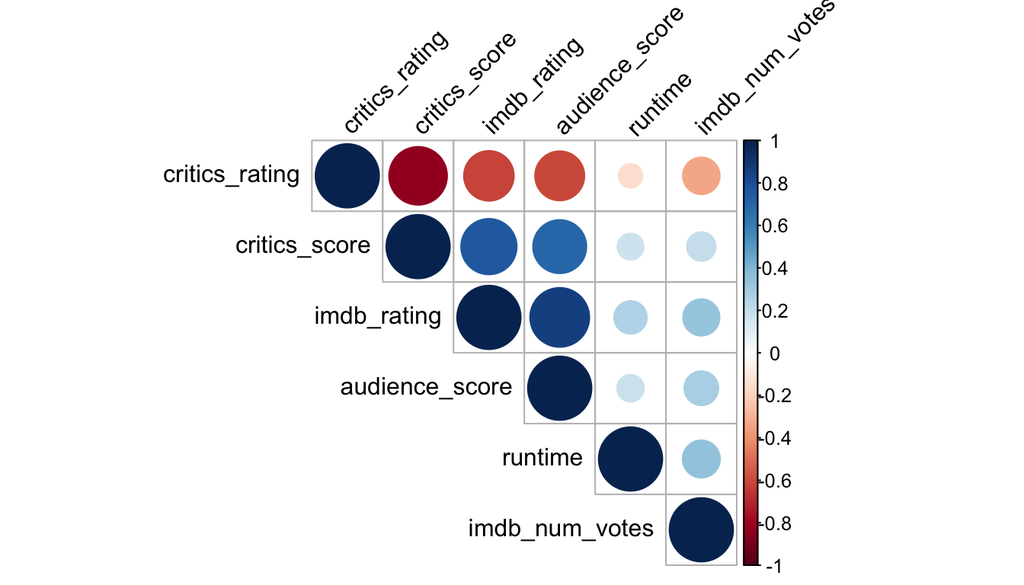

```r
library(corrplot)
corrplot(res, type = "upper", order = "hclust",
         tl.col = "black", tl.srt = 45)
```

Positive correlations are displayed in blue and negative correlations in red color. Color intensity and the size of the circle are proportional to the correlation coefficients. In the right side of the correlogram, the legend color shows the correlation coefficients and the corresponding colors.

The correlation between ‘audience_score’ and ‘imdb_rating’ is the strongest at .86 as also indicated in the correlation output above. The weakest correlation is between ‘critics_rating’ and ‘runtime’.

## Part 4: Modeling

Running the full model….

```r
movie_pop = lm(audience_score ~ runtime + critics_rating + imdb_rating  + imdb_num_votes + critics_score, data = movies_small)
```

## Part 5: Prediction

Utilizing Backwards Elinination using Adjusted R-Squared…

By removing ‘imdb_num_votes’ we can increase the Adjusted R-Squared from 0.7561 to 0.7565. Then, by removing ‘critics_score’ we increase Adjusted R-Square again to 0.7568.

```r
movie_pop = lm(audience_score ~ runtime + critics_rating + imdb_rating, data = movies_small)
summary(movie_pop)
```

```
##
## Call:
## lm(formula = audience_score ~ runtime + critics_rating + imdb_rating,
##     data = movies_small)
##
## Residuals:
##     Min      1Q  Median      3Q     Max
## -25.806  -6.487   0.555   5.611  51.209
##
## Coefficients:
##                 Estimate Std. Error t value Pr(>|t|)
## (Intercept)    -23.88543    4.30542  -5.548 4.22e-08 ***
## runtime         -0.05431    0.02090  -2.598  0.00959 **
## critics_rating  -2.79258    0.63707  -4.383 1.36e-05 ***
## imdb_rating     15.14198    0.47127  32.130  < 2e-16 ***
## ---
## Signif. codes:  0 '***' 0.001 '**' 0.01 '*' 0.05 '.' 0.1 ' ' 1
##
## Residual standard error: 9.972 on 647 degrees of freedom
## Multiple R-squared:  0.758,  Adjusted R-squared:  0.7568
## F-statistic: 675.4 on 3 and 647 DF,  p-value: < 2.2e-16
```

The rergression equation to predict and Audience Score is:

**Audience Score = -23.88 + runtime(-0.054) + critics_rating(-2.792) + imdb_rating(15.141)**

We can confirm the validity of this equation by inserting the mean of each numerical variable into the equation and outputing the average Audience Score.

```r
Aud_Score <- -23.88 + (mean(movies_small$runtime) * -0.054) +
  (mean(movies_small$critics_rating) * -2.792) +
  (mean(movies_small$imdb_rating) * 15.141)

Aud_Score
```

```
## [1] 62.39587
```

The outputed average Audience Score is 62.39, which is equal to the stated mean of the variable ’audience_score from above (summary(movies$audience_score).

Let’s choose a movie to run the model against. For example, if we look at the 2018 movie, Solo, directed by Ron Howard.

runtime: 135  
critics_rating: 3  
imbd_rating: 7.0

```r
Solo <- -23.88 + (135 * -0.054) + (3 * -2.792) +
  (7 * 15.141)

Solo
```

```
## [1] 66.441
```

Prediction Conclusion: Solo is a slightly, above average ‘popular’ movie.

## Part 6: Conclusion

Restating the research question, ‘given the 32 ’attributes’ what combination yields the highest predictive power of movie popularity?.

We can say that a combination ‘runtime’, ‘critics_rating’ and ‘imdb_rating’ can explain 75.68% of the variability of the ‘audience_score’, the variable that we are using as our proxy for movie popularity.